# R Beginners Course

## Downloading CDC Data in R

**Step 6:** Download all the files. Here we will use the *mapply* function from earlier.

```r
mapply(download.file, filenames, destfile = file.path(output.path, basename(filenames)))
```

The files should start downloading and will be saved in designated folder

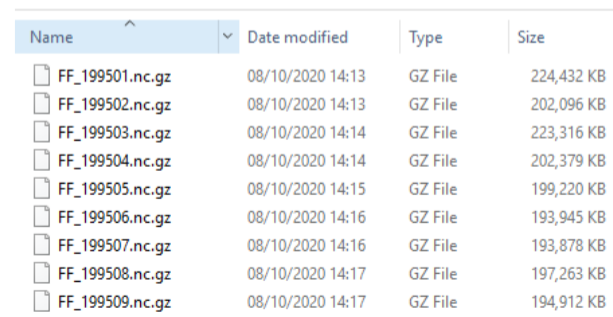

## Downloading CDC Data in R

**Step 7:** Uncompress (unzip) the files.

```r
mapply(gunzip, list.files(output.path, pattern = ".gz", full.names = TRUE))
```

Note that the default setting for the *gunzip* function will remove the zipped file after the output file has been fully created.

Let’s load the **terra** package.

```r
library(terra)
```

## Downloading CDC Data in R

**Step 8:** Data organisation: we will extract all of the data from each .nc file and save each layer as a separate *.tif* file in one folder. Let’s open the first file that we downloaded:

```r
nc_files <- list.files(output_path, pattern = ".nc", full.names = TRUE)
jan1995  <- rast(nc_files[1])
## Error in R_nc4_open: No such file or directory
## Warning: [rast] GDAL did not find an extent. Cells not equally spaced?
print(jan1995)
## class       : SpatRaster
## dimensions  : 938, 720, 744  (nrow, ncol, nlyr)
## resolution  : 0.001388889, 0.001066098  (x, y)
## extent      : 0, 1, 0, 1  (xmin, xmax, ymin, ymax)
## coord. ref. : +proj=lcc +lat_0=52 +lon_0=10 +lat_1=35 +lat_2=65 +x_0=4000000 +y_0=2800000 +datum=WGS84 +units=m +no_defs
## source      : FF_199501_CF.nc:FF
## varname     : FF (mean wind speed at 10 m height)
## names       : FF_1, FF_2, FF_3, FF_4, FF_5, FF_6, ...
## unit        :  m/s,  m/s,  m/s,  m/s,  m/s,  m/s, ...
## time        : 1995-01-01 00:00:00 to 1995-01-31 23:00:00
```

## Downloading CDC Data in R

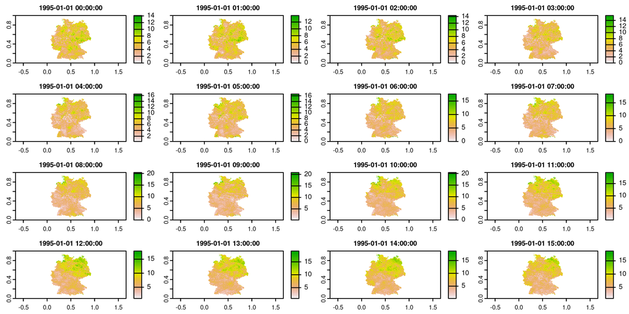

```r
plot(jan1995)
```

## Downloading CDC Data in R

**Step 8:** Convert the NCDF file to GeoTiff:

```r
processed.path <- "C:/Users/Documents/Wind/Processed"

for(i in 1:length(nc.files)){
  stacked.raster <- rast(nc.files[i])
  writeRaster(stacked.raster, paste0(processed.path, "/", names(stacked.raster), ".tif"), overwrite = TRUE)
}
```

[figure not shown]

# Downloading Products trough https

## Example 2: Downloading CHIRPSv2

CHIRPSv2 precipitation data are available at the following ftp: https://data.chc.ucsb.edu/products/CHIRPS-2.0

In this example, we will look at the monthly datasets: https://data.chc.ucsb.edu/products/CHIRPS-2.0/global_monthly/tifs/

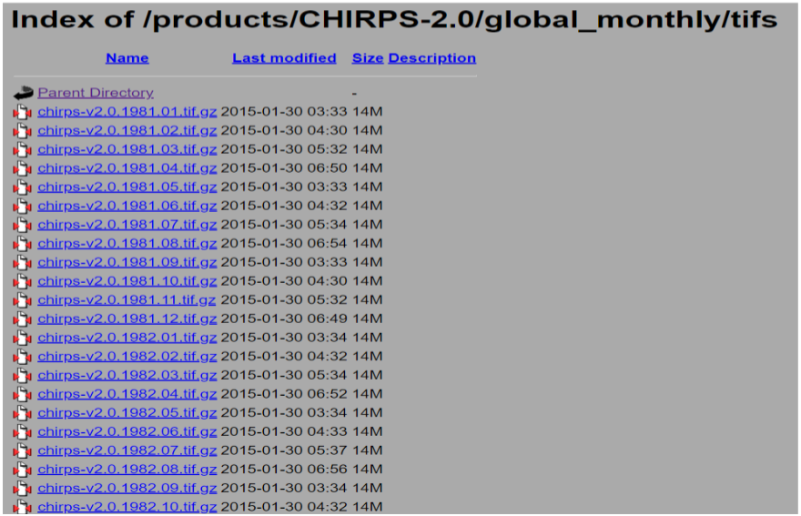

## Downloading CHIRPSv2

**Step 1:** We want to use the packages **httr** and **XML**.

```r
install.packages("httr")
install.packages("XML")

library(httr)
library(XML)
```

The **httr** package provides useful tools for working with HTTP organised by HTTP verbs, while the **XML** package provides approaches for both reading and creating XML and HTML documents.

## Downloading CHIRPSv2

**Step 2:** Define the https path.

```r
path <- "https://data.chc.ucsb.edu/products/CHIRPS-2.0/global_monthly/tifs/"
```

```r
output <- "C:/Users/Download_CHIRPS"
```

## Downloading CHIRPSv2

**Step 4:** We will use the function *GET* to retrieve the information from the specified url.

```r
df <- GET(path)
print(df)
## Response [https://data.chc.ucsb.edu/products/CHIRPS-2.0/global_monthly/tifs/]
##   Date: 2022-04-28 13:19
##   Status: 200
##   Content-Type: text/html;charset=ISO-8859-1
##   Size: 159 kB
## <!DOCTYPE HTML PUBLIC "-//W3C//DTD HTML 3.2 Final//EN">
## <html>
##  <head>
##   <title>Index of /products/CHIRPS-2.0/global_monthly/tifs</title>
##   <link rel="stylesheet" href="/css/chc-data.css" type="text/css">
##  </head>
##  <body>
##   <h1 id="indextitle">Index of /products/CHIRPS-2.0/global_monthly/tifs</h1>
##   <table id="indexlist">
##    <tr class="indexhead"><th class="indexcolicon"><img src="/icons/blank.gif"...
## ...
```

## Downloading CHIRPSv2

**Step 5:** We will use the function content to retrieve the contents of a requested url. The request can be retrieved as a raw object, as text, and parsed into an R object where possible. If as is not specified, content does its best to guess which output is most appropriate.